# Housing Market Linear Regression

The primary goal of this project is to create a linear model that estimates property value. As the dataset includes a downturn in the market, my plan is to first identify when the downturn happened, and then train linear models for before and after. If my estimation of the turn in the market is accurate, the two models should perform better than a single model based on the entire dataset.

## Importing required libraries

```r
require(MASS)
require(ISLR)
require(tidyverse)
require(corrplot)
require(lubridate)
```

## Read in and view the data

```r
house_dat = read.csv(url("https://utdallas.box.com/shared/static/of3rop2aqitzxz9ov8uvkg4inh8s6kws.csv"))
head(house_dat)
```

|  | Suburb | Address | Rooms | Type | Price | Method | SellerG | Date | Postcode | Regionname | Propertycount | Distance | CouncilArea |
| --- | --- | --- | --- | --- | --- | --- | --- | --- | --- | --- | --- | --- | --- |
| 1 | Abbotsford | 49 Lithgow St | 3 | h | 1490000 | S | Jellis | 1/04/2017 | 3067 | Northern Metropolitan | 4019 | 3.0 | Yarra City Council |
| 2 | Abbotsford | 59A Turner St | 3 | h | 1220000 | S | Marshall | 1/04/2017 | 3067 | Northern Metropolitan | 4019 | 3.0 | Yarra City Council |
| 3 | Abbotsford | 119B Yarra St | 3 | h | 1420000 | S | Nelson | 1/04/2017 | 3067 | Northern Metropolitan | 4019 | 3.0 | Yarra City Council |
| 4 | Aberfeldie | 68 Vida St | 3 | h | 1515000 | S | Barry | 1/04/2017 | 3040 | Western Metropolitan | 1543 | 7.5 | Moonee Valley City Council |
| 5 | Airport West | 92 Clydesdale Rd | 2 | h | 670000 | S | Nelson | 1/04/2017 | 3042 | Western Metropolitan | 3464 | 10.4 | Moonee Valley City Council |
| 6 | Airport West | 4/32 Earl St | 2 | t | 530000 | S | Jellis | 1/04/2017 | 3042 | Western Metropolitan | 3464 | 10.4 | Moonee Valley City Council |

## Clean and reformat the data

```r
clean_house_dat = house_dat[!is.na(house_dat$Price), ]
clean_house_dat$Date = dmy(clean_house_dat$Date)
clean_house_dat$Year_Month = format(as.Date(clean_house_dat$Date), "%Y-%m")
clean_house_dat$Year = format(as.Date(clean_house_dat$Date), "%Y")
clean_house_dat$Month = format(as.Date(clean_house_dat$Date), "%m")
clean_house_dat$Day = format(as.Date(clean_house_dat$Date), "%d")
head(clean_house_dat)
```

|  | Suburb | Address | Rooms | Type | Price | Method | SellerG | Date | Postcode | Regionname | Propertycount | Distance | CouncilArea | Year_Month | Year | Month | Day |
| --- | --- | --- | --- | --- | --- | --- | --- | --- | --- | --- | --- | --- | --- | --- | --- | --- | --- |
| 1 | Abbotsford | 49 Lithgow St | 3 | h | 1490000 | S | Jellis | 2017-04-01 | 3067 | Northern Metropolitan | 4019 | 3.0 | Yarra City Council | 2017-04 | 2017 | 04 | 01 |
| 2 | Abbotsford | 59A Turner St | 3 | h | 1220000 | S | Marshall | 2017-04-01 | 3067 | Northern Metropolitan | 4019 | 3.0 | Yarra City Council | 2017-04 | 2017 | 04 | 01 |
| 3 | Abbotsford | 119B Yarra St | 3 | h | 1420000 | S | Nelson | 2017-04-01 | 3067 | Northern Metropolitan | 4019 | 3.0 | Yarra City Council | 2017-04 | 2017 | 04 | 01 |
| 4 | Aberfeldie | 68 Vida St | 3 | h | 1515000 | S | Barry | 2017-04-01 | 3040 | Western Metropolitan | 1543 | 7.5 | Moonee Valley City Council | 2017-04 | 2017 | 04 | 01 |
| 5 | Airport West | 92 Clydesdale Rd | 2 | h | 670000 | S | Nelson | 2017-04-01 | 3042 | Western Metropolitan | 3464 | 10.4 | Moonee Valley City Council | 2017-04 | 2017 | 04 | 01 |
| 6 | Airport West | 4/32 Earl St | 2 | t | 530000 | S | Jellis | 2017-04-01 | 3042 | Western Metropolitan | 3464 | 10.4 | Moonee Valley City Council | 2017-04 | 2017 | 04 | 01 |

## Need to identify when the market turned. Creating visualizations

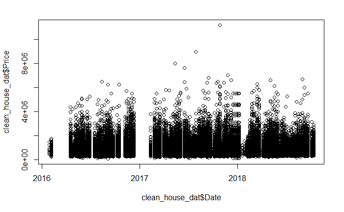

```r
#Plotting price vs date
plot(clean_house_dat$Date, clean_house_dat$Price)
```

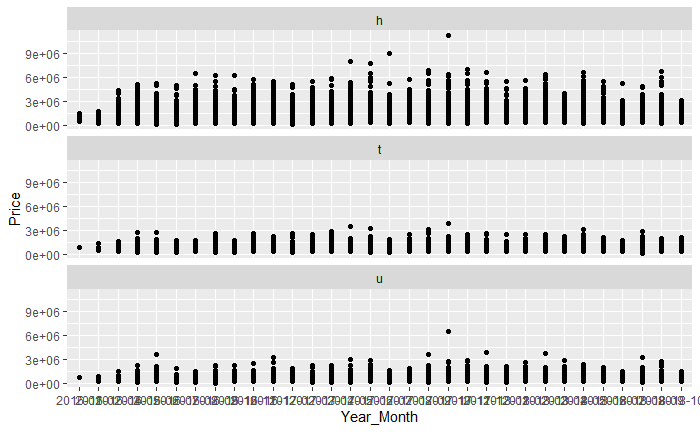

```r
#Plot the price vs date for each type, doesn't give much info
ggplot(data = clean_house_dat) + geom_point(mapping=aes(x=Year_Month, y=Price)) + facet_wrap(~ Type, nrow=3)
```

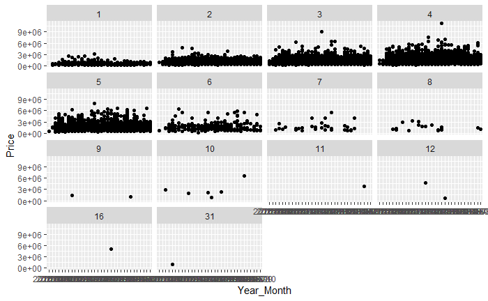

```r
#Same as the above, but seperate by number of rooms
ggplot(data = clean_house_dat) + geom_point(mapping=aes(x=Year_Month, y=Price)) + facet_wrap(~ Rooms)
```

The above indicates the vast majority of houses have less than 7 rooms, verifying and removing them from the dataset

```r
table(clean_house_dat$Rooms)
```

```
    1     2     3     4     5     6     7     8     9    10    11    12    16    31
 1670 10674 21812 11576  2350   283    36    19     2     6     1     2     1     1
```

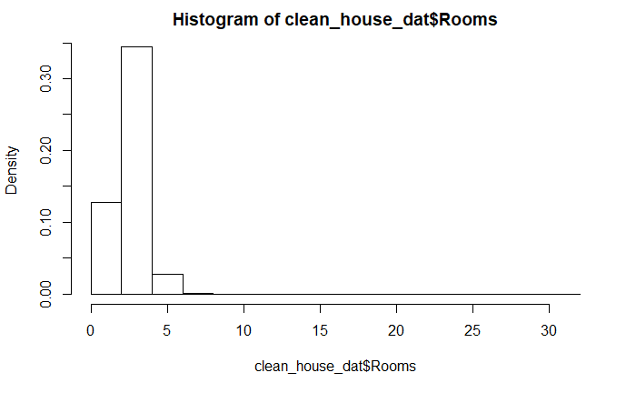

```r
hist(clean_house_dat$Rooms, freq = FALSE)
```

```r
#The vast majority of the houses have less than 7 rooms, limiting to only those - removes 68 rows
clean_house_dat = clean_house_dat[clean_house_dat$Rooms < 7, ]
```

Visualizing the updated data. Looking at the prices year over year might help us narrow our search to a single year

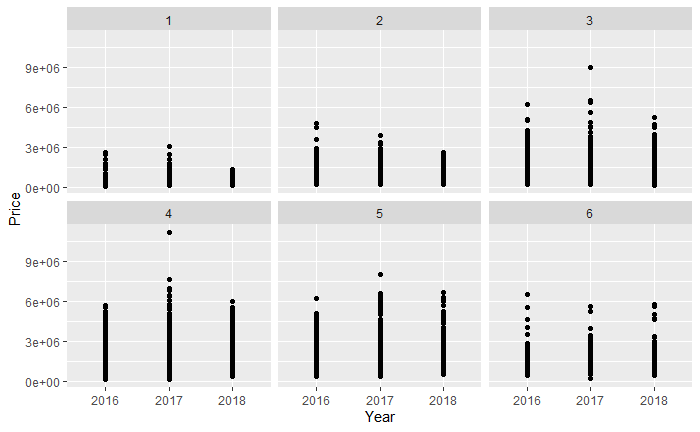

```r
#Viewing the updated data from year over year perspective might help use see which year had the change
ggplot(data = clean_house_dat) + geom_point(mapping=aes(x=Year, y=Price)) + facet_wrap(~ Rooms)
```

Based on the above, we can assume the downturn happened between 2017 and 2018, plotting the above as month over month in that timeframe

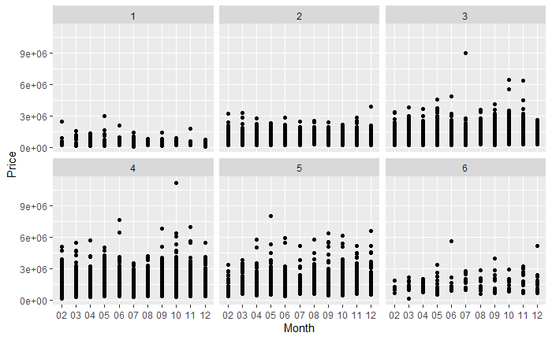

```r
one_year_dat = clean_house_dat[clean_house_dat$Year == 2017, ]
ggplot(data = one_year_dat) + geom_point(mapping=aes(x=Month, y=Price)) + facet_wrap(~ Rooms)
```

Using individual house prices isn’t giving much clarity. Let’s try mean and median prices

```r
#Read in the data as tibbles
house_df = as_tibble(clean_house_dat)
year_df = as_tibble(one_year_dat)
#Cleaning up memory
rm(list=c("house_dat", "clean_house_dat", "one_year_dat"))
```

Month over month data for MEAN

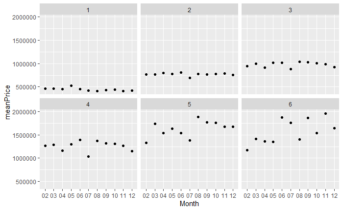

```r
ggplot(year_df %>% group_by(Month, Rooms) %>% summarise(meanPrice = mean(Price))) +
    geom_point(mapping=aes(x=Month, y=meanPrice)) + facet_wrap(~ Rooms)
```

Month over month data for MEDIAN

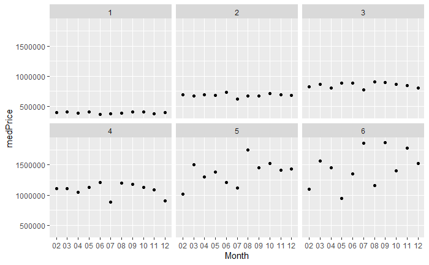

```r
ggplot(year_df %>% group_by(Month, Rooms) %>% summarise(medPrice = median(Price))) +
    geom_point(mapping=aes(x=Month, y=medPrice)) + facet_wrap(~ Rooms)
```

## The above, particularly the 3 and 4 bedroom plots, indicate a drop in July 2017 followed by a market decline. Let’s plot the same month over month data for the entire timeline and see if we can identify the same drop.

Full timeline month over month MEAN

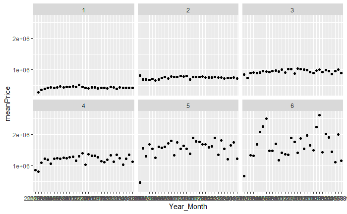

```r
ggplot(house_df %>% group_by(Year_Month, Rooms) %>% summarise(meanPrice = mean(Price))) +
    geom_point(mapping=aes(x=Year_Month, y=meanPrice)) + facet_wrap(~ Rooms)
```

Full timeline month over month MEDIAN

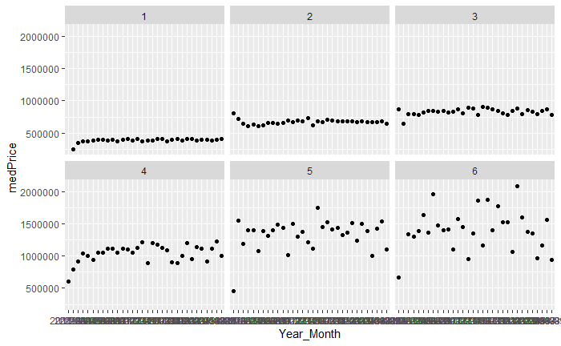

```r
ggplot(house_df %>% group_by(Year_Month, Rooms) %>% summarise(medPrice = median(Price))) +
    geom_point(mapping=aes(x=Year_Month, y=medPrice)) + facet_wrap(~ Rooms)
```

## For the 1-4 bedroom cases we can see a generally positive trend prior to July 2017, followed by instability and a negative trend afterwards

Assuming July 2017 is the turning point, we need to separate the data to before and after

```r
before_df = filter(house_df, Date < "2017-07-01")
after_df = filter(house_df, Date >= "2017-08-01")
```

## At this point we want to identify what features to use in our linear model

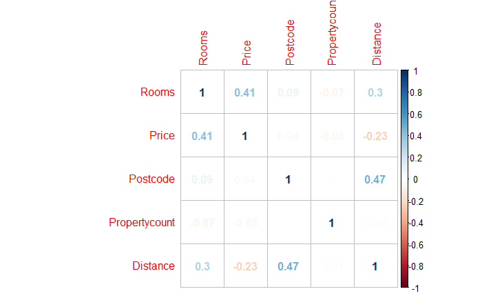

```r
#Time to see what the correlation is between the different numeric variables and price
before_M <- cor(before_df[, sapply(house_df, is.numeric)])
after_M <- cor(after_df[, sapply(house_df, is.numeric)])
corrplot(before_M, method = "number")
```

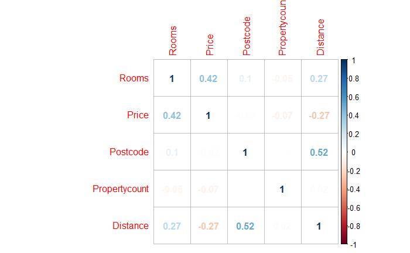

```r
corrplot(after_M, method = "number")
```

We can see that Rooms and Distance have high correlation in both cases, let’s start with those

```r
before.fit=lm(before_df$Price ~ before_df$Rooms)
summary(before.fit)
```

```
Call:
lm(formula = before_df$Price ~ before_df$Rooms)

Residuals:
     Min       1Q   Median       3Q      Max
-1567891  -321775  -104736   191187  6504148

Coefficients:
                Estimate Std. Error t value Pr(>|t|)
(Intercept)       185658      12804   14.50   <2e-16 ***
before_df$Rooms   262039       4010   65.34   <2e-16 ***
---
Signif. codes:  0 â€˜***â€™ 0.001 â€˜**â€™ 0.01 â€˜*â€™ 0.05 â€˜.â€™ 0.1 â€˜ â€™ 1

Residual standard error: 537100 on 21023 degrees of freedom
Multiple R-squared:  0.1688,    Adjusted R-squared:  0.1688
F-statistic:  4269 on 1 and 21023 DF,  p-value: < 2.2e-16
```

```r
after.fit=lm(after_df$Price ~ after_df$Rooms)
summary(after.fit)
```

```
Call:
lm(formula = after_df$Price ~ after_df$Rooms)

Residuals:
     Min       1Q   Median       3Q      Max
-1386765  -327584  -102857   191869  9932689

Coefficients:
               Estimate Std. Error t value Pr(>|t|)
(Intercept)      168404      11978   14.06   <2e-16 ***
after_df$Rooms   274727       3733   73.59   <2e-16 ***
---
Signif. codes:  0 â€˜***â€™ 0.001 â€˜**â€™ 0.01 â€˜*â€™ 0.05 â€˜.â€™ 0.1 â€˜ â€™ 1

Residual standard error: 542900 on 25536 degrees of freedom
Multiple R-squared:  0.175, Adjusted R-squared:  0.175
F-statistic:  5416 on 1 and 25536 DF,  p-value: < 2.2e-16
```

```r
#Adding Distance to the models
before.fit = update(before.fit, . ~ . + before_df$Distance)
summary(before.fit)
```

```
Call:
lm(formula = before_df$Price ~ before_df$Rooms + before_df$Distance)

Residuals:
     Min       1Q   Median       3Q      Max
-1648915  -300981   -87963   193217  6232341

Coefficients:
                   Estimate Std. Error t value Pr(>|t|)
(Intercept)        350510.5    11952.7   29.32   <2e-16 ***
before_df$Rooms    337220.0     3836.7   87.89   <2e-16 ***
before_df$Distance -32018.0      491.9  -65.09   <2e-16 ***
---
Signif. codes:  0 â€˜***â€™ 0.001 â€˜**â€™ 0.01 â€˜*â€™ 0.05 â€˜.â€™ 0.1 â€˜ â€™ 1

Residual standard error: 490000 on 21022 degrees of freedom
Multiple R-squared:  0.3082,    Adjusted R-squared:  0.3081
F-statistic:  4683 on 2 and 21022 DF,  p-value: < 2.2e-16
```

```r
after.fit = update(after.fit, . ~ . + after_df$Distance)
summary(after.fit)
```

```
Call:
lm(formula = after_df$Price ~ after_df$Rooms + after_df$Distance)

Residuals:
     Min       1Q   Median       3Q      Max
-1398392  -290181   -84368   184384  9783271

Coefficients:
                  Estimate Std. Error t value Pr(>|t|)
(Intercept)       354478.3    10971.2   32.31   <2e-16 ***
after_df$Rooms    350831.2     3474.7  100.97   <2e-16 ***
after_df$Distance -32483.2      407.7  -79.68   <2e-16 ***
---
Signif. codes:  0 â€˜***â€™ 0.001 â€˜**â€™ 0.01 â€˜*â€™ 0.05 â€˜.â€™ 0.1 â€˜ â€™ 1

Residual standard error: 485900 on 25535 degrees of freedom
Multiple R-squared:  0.3393,    Adjusted R-squared:  0.3392
F-statistic:  6556 on 2 and 25535 DF,  p-value: < 2.2e-16
```

## The following section is iterating on the models by adding/removing features based on performance

```r
#Adding Type to the models
before.fit = update(before.fit, . ~ . + before_df$Type)
summary(before.fit)
```

```
Call:
lm(formula = before_df$Price ~ before_df$Rooms + before_df$Distance +
    before_df$Type)

Residuals:
     Min       1Q   Median       3Q      Max
-1358783  -297208   -74652   190619  6280964

Coefficients:
                    Estimate Std. Error t value Pr(>|t|)
(Intercept)         639417.1    15312.8   41.76   <2e-16 ***
before_df$Rooms     272276.1     4380.5   62.16   <2e-16 ***
before_df$Distance  -33543.0      484.9  -69.17   <2e-16 ***
before_df$Typet    -154269.4    11434.0  -13.49   <2e-16 ***
before_df$Typeu    -290117.0    10187.2  -28.48   <2e-16 ***
---
Signif. codes:  0 â€˜***â€™ 0.001 â€˜**â€™ 0.01 â€˜*â€™ 0.05 â€˜.â€™ 0.1 â€˜ â€™ 1

Residual standard error: 480300 on 21020 degrees of freedom
Multiple R-squared:  0.3355,    Adjusted R-squared:  0.3354
F-statistic:  2653 on 4 and 21020 DF,  p-value: < 2.2e-16
```

```r
after.fit = update(after.fit, . ~ . + after_df$Type)
summary(after.fit)
```

```
Call:
lm(formula = after_df$Price ~ after_df$Rooms + after_df$Distance +
    after_df$Type)

Residuals:
     Min       1Q   Median       3Q      Max
-1293090  -286769   -75920   181545  9769688

Coefficients:
                   Estimate Std. Error t value Pr(>|t|)
(Intercept)        620719.9    14184.7   43.76   <2e-16 ***
after_df$Rooms     291389.1     4010.1   72.66   <2e-16 ***
after_df$Distance  -33901.4      404.1  -83.89   <2e-16 ***
after_df$Typet    -150991.3    10035.6  -15.05   <2e-16 ***
after_df$Typeu    -260444.6     9369.8  -27.80   <2e-16 ***
---
Signif. codes:  0 â€˜***â€™ 0.001 â€˜**â€™ 0.01 â€˜*â€™ 0.05 â€˜.â€™ 0.1 â€˜ â€™ 1

Residual standard error: 478000 on 25533 degrees of freedom
Multiple R-squared:  0.3605,    Adjusted R-squared:  0.3604
F-statistic:  3598 on 4 and 25533 DF,  p-value: < 2.2e-16
```

```r
#Adding Regionname to the models
before.fit = update(before.fit, . ~ . + before_df$Regionname)
summary(before.fit)
```

```
Call:
lm(formula = before_df$Price ~ before_df$Rooms + before_df$Distance +
    before_df$Type + before_df$Regionname)

Residuals:
     Min       1Q   Median       3Q      Max
-1670589  -239984   -52063   161371  5934816

Coefficients:
                                                Estimate Std. Error t value Pr(>|t|)
(Intercept)                                     900753.8    16284.6  55.313  < 2e-16 ***
before_df$Rooms                                 251129.6     3753.4  66.908  < 2e-16 ***
before_df$Distance                              -41549.3      558.8 -74.361  < 2e-16 ***
before_df$Typet                                -224045.3     9691.2 -23.118  < 2e-16 ***
before_df$Typeu                                -441669.8     8760.9 -50.414  < 2e-16 ***
before_df$RegionnameEastern Victoria            260918.4    37795.6   6.903 5.22e-12 ***
before_df$RegionnameNorthern Metropolitan      -301596.7     9193.4 -32.806  < 2e-16 ***
before_df$RegionnameNorthern Victoria           185904.8    40659.9   4.572 4.85e-06 ***
before_df$RegionnameSouth-Eastern Metropolitan  191150.4    12728.1  15.018  < 2e-16 ***
before_df$RegionnameSouthern Metropolitan       257795.8     9233.8  27.919  < 2e-16 ***
before_df$RegionnameWestern Metropolitan       -392048.9     9772.8 -40.116  < 2e-16 ***
before_df$RegionnameWestern Victoria            -93554.5    59607.8  -1.570    0.117
---
Signif. codes:  0 â€˜***â€™ 0.001 â€˜**â€™ 0.01 â€˜*â€™ 0.05 â€˜.â€™ 0.1 â€˜ â€™ 1

Residual standard error: 405600 on 21013 degrees of freedom
Multiple R-squared:  0.5262,    Adjusted R-squared:  0.5259
F-statistic:  2121 on 11 and 21013 DF,  p-value: < 2.2e-16
```

```r
after.fit = update(after.fit, . ~ . + after_df$Regionname)
summary(after.fit)
```

```
Call:
lm(formula = after_df$Price ~ after_df$Rooms + after_df$Distance +
    after_df$Type + after_df$Regionname)

Residuals:
     Min       1Q   Median       3Q      Max
-1495557  -234138   -54374   149903  9400110

Coefficients:
                                               Estimate Std. Error t value Pr(>|t|)
(Intercept)                                    844378.5    15016.7  56.229  < 2e-16 ***
after_df$Rooms                                 264798.7     3466.2  76.393  < 2e-16 ***
after_df$Distance                              -37738.4      455.6 -82.826  < 2e-16 ***
after_df$Typet                                -220059.0     8591.1 -25.615  < 2e-16 ***
after_df$Typeu                                -405905.9     8125.0 -49.958  < 2e-16 ***
after_df$RegionnameEastern Victoria            214429.7    29581.1   7.249 4.32e-13 ***
after_df$RegionnameNorthern Metropolitan      -256391.3     8465.2 -30.288  < 2e-16 ***
after_df$RegionnameNorthern Victoria           134014.8    24743.2   5.416 6.14e-08 ***
after_df$RegionnameSouth-Eastern Metropolitan  180503.3    12114.1  14.900  < 2e-16 ***
after_df$RegionnameSouthern Metropolitan       292569.6     8898.9  32.877  < 2e-16 ***
after_df$RegionnameWestern Metropolitan       -345882.0     8869.9 -38.995  < 2e-16 ***
after_df$RegionnameWestern Victoria            -56079.7    39080.9  -1.435    0.151
---
Signif. codes:  0 â€˜***â€™ 0.001 â€˜**â€™ 0.01 â€˜*â€™ 0.05 â€˜.â€™ 0.1 â€˜ â€™ 1

Residual standard error: 407400 on 25526 degrees of freedom
Multiple R-squared:  0.5357,    Adjusted R-squared:  0.5355
F-statistic:  2677 on 11 and 25526 DF,  p-value: < 2.2e-16
```

Regionname brough up R^2, but dropped F-statistic by a lot. Dropping regionname

```r
#Dropping regionname
before.fit = update(before.fit, . ~ . - before_df$Regionname)
after.fit = update(after.fit, . ~ . - after_df$Regionname)
#Adding Suburb to the models
before.fit = update(before.fit, . ~ . + before_df$Suburb)
summary(before.fit)
```

```
Call:
lm(formula = before_df$Price ~ before_df$Rooms + before_df$Distance +
    before_df$Type + before_df$Suburb)

Residuals:
     Min       1Q   Median       3Q      Max
-1409165  -178405   -27091   129648  5702405

Coefficients: (1 not defined because of singularities)
                                   Estimate Std. Error t value Pr(>|t|)
(Intercept)                          858489      85327  10.061  < 2e-16 ***
before_df$Rooms                      244001       3411  71.537  < 2e-16 ***
before_df$Distance                   -82764      15486  -5.345 9.16e-08 ***
before_df$Typet                     -251439       8642 -29.095  < 2e-16 ***
before_df$Typeu                     -479072       7933 -60.393  < 2e-16 ***
before_df$SuburbAberfeldie           406381      70202   5.789 7.19e-09 ***
before_df$SuburbAirport West         158102      91049   1.736 0.082497 .
before_df$SuburbAlbanvale            -17959     180491  -0.099 0.920742
before_df$SuburbAlbert Park          687025      60543  11.348  < 2e-16 ***
before_df$SuburbAlbion                94140     101118   0.931 0.351870
before_df$SuburbAlphington           347930      59584   5.839 5.32e-09 ***
before_df$SuburbAltona               328018     101328   3.237 0.001209 **
before_df$SuburbAltona Meadows       251317     177641   1.415 0.157157
before_df$SuburbAltona North         -30103      77665  -0.388 0.698319
before_df$SuburbArdeer                12603     136317   0.092 0.926338
before_df$SuburbArmadale             821118      45669  17.980  < 2e-16 ***
before_df$SuburbAscot Vale           -76598      41164  -1.861 0.062786 .
before_df$SuburbAshburton            879775      89227   9.860  < 2e-16 ***
before_df$SuburbAshwood              465078      91797   5.066 4.09e-07 ***
before_df$SuburbAspendale           1246790     257742   4.837 1.33e-06 ***
before_df$SuburbAspendale Gardens   1001496     265049   3.779 0.000158 ***
before_df$SuburbAttwood              332048     197615   1.680 0.092919 .
before_df$SuburbAvondale Heights      -1546      79242  -0.020 0.984437
before_df$SuburbBalaclava            245618      79112   3.105 0.001907 **
before_df$SuburbBalwyn               919642      55669  16.520  < 2e-16 ***
before_df$SuburbBalwyn North         847811      77321  10.965  < 2e-16 ***
before_df$SuburbBayswater           1138638     285566   3.987 6.71e-05 ***
before_df$SuburbBayswater North      950706     291444   3.262 0.001108 **
before_df$SuburbBeaconsfield        2130113     545998   3.901 9.60e-05 ***
before_df$SuburbBeaconsfield Upper  2152524     590130   3.648 0.000265 ***
```

[output cut: 162 more lines]

```
before_df$SuburbKnoxfield           1125639     295558   3.809 0.000140 ***
before_df$SuburbKooyong              511696     177628   2.881 0.003972 **
before_df$SuburbKurunjang           1213334     439086   2.763 0.005727 **
before_df$SuburbLalor                361314     175428   2.060 0.039448 *
before_df$SuburbLangwarrin          2486532     572173   4.346 1.39e-05 ***
before_df$SuburbLaverton              28854     295712   0.098 0.922271
before_df$SuburbLilydale            1525759     413290   3.692 0.000223 ***
before_df$SuburbLower Plenty         531474     162478   3.271 0.001073 **
 [ reached getOption("max.print") -- omitted 150 rows ]
---
Signif. codes:  0 â€˜***â€™ 0.001 â€˜**â€™ 0.01 â€˜*â€™ 0.05 â€˜.â€™ 0.1 â€˜ â€™ 1

Residual standard error: 351500 on 20676 degrees of freedom
Multiple R-squared:  0.6499,    Adjusted R-squared:  0.644
F-statistic: 110.3 on 348 and 20676 DF,  p-value: < 2.2e-16
```

```r
after.fit = update(after.fit, . ~ . + after_df$Suburb)
summary(after.fit)
```

```
Call:
lm(formula = after_df$Price ~ after_df$Rooms + after_df$Distance +
    after_df$Type + after_df$Suburb)

Residuals:
     Min       1Q   Median       3Q      Max
-1902395  -174189   -24496   121097  8664419

Coefficients: (1 not defined because of singularities)
                                  Estimate Std. Error t value Pr(>|t|)
(Intercept)                         802712      85274   9.413  < 2e-16 ***
after_df$Rooms                      258251       3137  82.324  < 2e-16 ***
after_df$Distance                   -70107      15151  -4.627 3.72e-06 ***
after_df$Typet                     -226935       7681 -29.545  < 2e-16 ***
after_df$Typeu                     -431584       7299 -59.130  < 2e-16 ***
after_df$SuburbAberfeldie           386386      62697   6.163 7.26e-10 ***
after_df$SuburbAirport West          53139      85805   0.619 0.535722
after_df$SuburbAlbanvale            -30400     176635  -0.172 0.863357
after_df$SuburbAlbert Park          732625      62309  11.758  < 2e-16 ***
after_df$SuburbAlbion                32075      95966   0.334 0.738207
after_df$SuburbAlphington           328097      60063   5.463 4.74e-08 ***
after_df$SuburbAltona               221595      97784   2.266 0.023449 *
after_df$SuburbAltona Meadows       128653     163816   0.785 0.432255
after_df$SuburbAltona North         -57892      77346  -0.748 0.454179
after_df$SuburbArdeer                -9926     123227  -0.081 0.935803
after_df$SuburbArmadale             778127      44109  17.641  < 2e-16 ***
after_df$SuburbAscot Vale           -71491      39116  -1.828 0.067611 .
after_df$SuburbAshburton            719137      86853   8.280  < 2e-16 ***
after_df$SuburbAshwood              394439      87169   4.525 6.07e-06 ***
after_df$SuburbAspendale            940006     250190   3.757 0.000172 ***
after_df$SuburbAspendale Gardens    749353     252891   2.963 0.003048 **
after_df$SuburbAttwood              133890     186922   0.716 0.473819
after_df$SuburbAvondale Heights     -72633      75068  -0.968 0.333268
after_df$SuburbBacchus Marsh       1559713     502415   3.104 0.001909 **
after_df$SuburbBalaclava            210593      56190   3.748 0.000179 ***
after_df$SuburbBalwyn               952547      52542  18.129  < 2e-16 ***
after_df$SuburbBalwyn North         763174      72863  10.474  < 2e-16 ***
after_df$SuburbBayswater            917249     274683   3.339 0.000841 ***
after_df$SuburbBayswater North      860248     281226   3.059 0.002224 **
after_df$SuburbBeaconsfield Upper  1976803     629073   3.142 0.001678 **
```

[output cut: 162 more lines]

```
after_df$SuburbKeilor Park         -341399     110075  -3.102 0.001927 **
after_df$SuburbKensington           -95523      50218  -1.902 0.057162 .
after_df$SuburbKew                  627849      32409  19.373  < 2e-16 ***
after_df$SuburbKew East             581264      52234  11.128  < 2e-16 ***
after_df$SuburbKeysborough          942510     304746   3.093 0.001985 **
after_df$SuburbKilsyth             1024406     320354   3.198 0.001387 **
after_df$SuburbKilsyth South       1008820     470680   2.143 0.032097 *
after_df$SuburbKings Park          -128618     151126  -0.851 0.394742
 [ reached getOption("max.print") -- omitted 160 rows ]
---
Signif. codes:  0 â€˜***â€™ 0.001 â€˜**â€™ 0.01 â€˜*â€™ 0.05 â€˜.â€™ 0.1 â€˜ â€™ 1

Residual standard error: 351700 on 25179 degrees of freedom
Multiple R-squared:  0.6587,    Adjusted R-squared:  0.6538
F-statistic: 135.7 on 358 and 25179 DF,  p-value: < 2.2e-16
```

Adding suburb complicated the model and dropped the F-Statistic by a lot, but almost doubled our R^2 value. Keeping it for now

At this point I tried to use postcode instead of suburb, but postcode is read in as a number and not a category. Couldn’t find a clean way to transform it, so I’ve removed that. Afterwards I added each of the remaining variables, but they had trivial or negative impact on the model.

## Proceeding with the current model

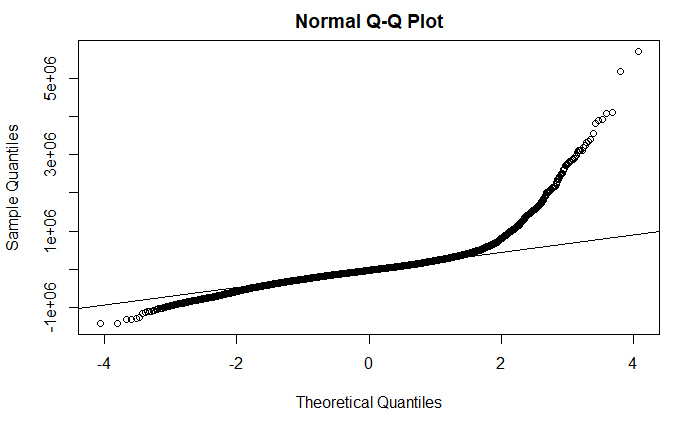

```r
#Assuming this is the best model we can make, time to visualize
qqnorm(resid(before.fit))
qqline(resid(before.fit))
```

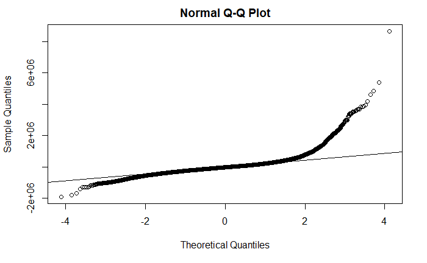

```r
qqnorm(resid(after.fit))
qqline(resid(after.fit))
```

Based on the Q-Q Plot, the data seems to not be linear, trying polynomial transformation

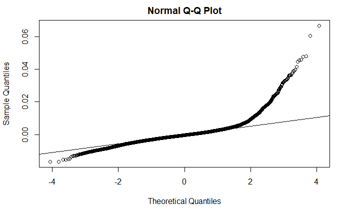

```r
before.poly = update(before.fit, poly(.) ~ .)
qqnorm(resid(before.poly))
qqline(resid(before.poly))
```

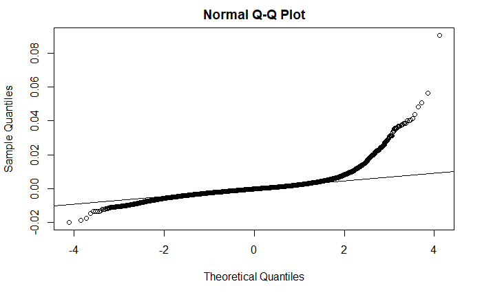

```r
after.poly = update(after.fit, poly(.) ~ .)
qqnorm(resid(after.poly))
qqline(resid(after.poly))
```

Polynomial looks to match about as well as linear. Trying a natural log (ln) transformation

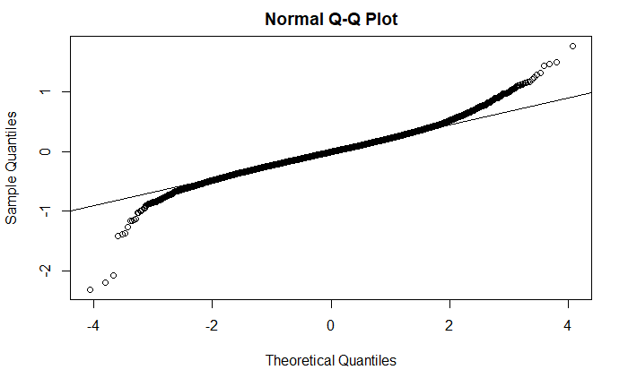

```r
before.ln = update(before.fit, log1p(.) ~ .)
qqnorm(resid(before.ln))
qqline(resid(before.ln))
```

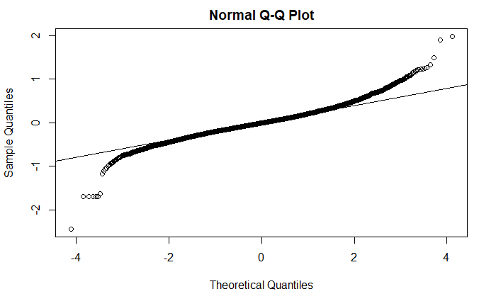

```r
after.ln = update(after.fit, log1p(.) ~ .)
qqnorm(resid(after.ln))
qqline(resid(after.ln))
```

Both transformations are imperfect, but the ln transformation seems to be a better predictor, and very accurate around the median

```r
#Getting summary data for the ln transformation
summary(before.ln)
```

```
Call:
lm(formula = log1p(before_df$Price) ~ before_df$Rooms + before_df$Distance +
    before_df$Type + before_df$Suburb)

Residuals:
     Min       1Q   Median       3Q      Max
-2.31400 -0.15527 -0.00363  0.14946  1.77635

Coefficients: (1 not defined because of singularities)
                                     Estimate Std. Error t value Pr(>|t|)
(Intercept)                        13.6524063  0.0606818 224.984  < 2e-16 ***
before_df$Rooms                     0.2126861  0.0024257  87.680  < 2e-16 ***
before_df$Distance                 -0.0747201  0.0110131  -6.785 1.19e-11 ***
before_df$Typet                    -0.2166044  0.0061459 -35.244  < 2e-16 ***
before_df$Typeu                    -0.5233816  0.0056414 -92.775  < 2e-16 ***
before_df$SuburbAberfeldie          0.2986632  0.0499256   5.982 2.24e-09 ***
before_df$SuburbAirport West        0.1143718  0.0647512   1.766 0.077356 .
before_df$SuburbAlbanvale          -0.2413946  0.1283598  -1.881 0.060039 .
before_df$SuburbAlbert Park         0.4390783  0.0430563  10.198  < 2e-16 ***
before_df$SuburbAlbion             -0.0638815  0.0719120  -0.888 0.374374
before_df$SuburbAlphington          0.2136878  0.0423743   5.043 4.63e-07 ***
before_df$SuburbAltona              0.2820146  0.0720616   3.914 9.13e-05 ***
before_df$SuburbAltona Meadows      0.0894318  0.1263328   0.708 0.479011
before_df$SuburbAltona North       -0.0503066  0.0552331  -0.911 0.362408
before_df$SuburbArdeer             -0.1335877  0.0969448  -1.378 0.168226
before_df$SuburbArmadale            0.5143785  0.0324784  15.838  < 2e-16 ***
before_df$SuburbAscot Vale         -0.0645110  0.0292745  -2.204 0.027559 *
before_df$SuburbAshburton           0.7348832  0.0634557  11.581  < 2e-16 ***
before_df$SuburbAshwood             0.4598352  0.0652835   7.044 1.93e-12 ***
before_df$SuburbAspendale           1.1165155  0.1832988   6.091 1.14e-09 ***
before_df$SuburbAspendale Gardens   0.9160430  0.1884949   4.860 1.18e-06 ***
before_df$SuburbAttwood             0.2105608  0.1405383   1.498 0.134085
before_df$SuburbAvondale Heights   -0.0035651  0.0563549  -0.063 0.949559
before_df$SuburbBalaclava           0.1111570  0.0562620   1.976 0.048202 *
before_df$SuburbBalwyn              0.6236167  0.0395902  15.752  < 2e-16 ***
before_df$SuburbBalwyn North        0.6674337  0.0549882  12.138  < 2e-16 ***
before_df$SuburbBayswater           1.0121146  0.2030858   4.984 6.29e-07 ***
before_df$SuburbBayswater North     0.8168240  0.2072666   3.941 8.14e-05 ***
before_df$SuburbBeaconsfield        1.8401093  0.3882975   4.739 2.16e-06 ***
before_df$SuburbBeaconsfield Upper  1.9191602  0.4196833   4.573 4.84e-06 ***
```

[output cut: 162 more lines]

```
before_df$SuburbKnoxfield           1.0636796  0.2101921   5.061 4.22e-07 ***
before_df$SuburbKooyong             0.4501640  0.1263241   3.564 0.000367 ***
before_df$SuburbKurunjang           0.6408492  0.3122654   2.052 0.040157 *
before_df$SuburbLalor               0.1907583  0.1247596   1.529 0.126278
before_df$SuburbLangwarrin          2.0880398  0.4069126   5.131 2.90e-07 ***
before_df$SuburbLaverton           -0.2042430  0.2103019  -0.971 0.331465
before_df$SuburbLilydale            1.2245166  0.2939195   4.166 3.11e-05 ***
before_df$SuburbLower Plenty        0.4703194  0.1155498   4.070 4.71e-05 ***
 [ reached getOption("max.print") -- omitted 150 rows ]
---
Signif. codes:  0 â€˜***â€™ 0.001 â€˜**â€™ 0.01 â€˜*â€™ 0.05 â€˜.â€™ 0.1 â€˜ â€™ 1

Residual standard error: 0.25 on 20676 degrees of freedom
Multiple R-squared:  0.7629,    Adjusted R-squared:  0.7589
F-statistic: 191.2 on 348 and 20676 DF,  p-value: < 2.2e-16
```

```r
summary(after.ln)
```

```
Call:
lm(formula = log1p(after_df$Price) ~ after_df$Rooms + after_df$Distance +
    after_df$Type + after_df$Suburb)

Residuals:
     Min       1Q   Median       3Q      Max
-2.43806 -0.13839 -0.00755  0.12762  1.98519

Coefficients: (1 not defined because of singularities)
                                   Estimate Std. Error t value Pr(>|t|)
(Intercept)                       13.661960   0.055724 245.174  < 2e-16 ***
after_df$Rooms                     0.213668   0.002050 104.232  < 2e-16 ***
after_df$Distance                 -0.068339   0.009901  -6.903 5.23e-12 ***
after_df$Typet                    -0.189143   0.005019 -37.684  < 2e-16 ***
after_df$Typeu                    -0.473771   0.004770 -99.332  < 2e-16 ***
after_df$SuburbAberfeldie          0.290048   0.040971   7.079 1.49e-12 ***
after_df$SuburbAirport West        0.079374   0.056071   1.416 0.156900
after_df$SuburbAlbanvale          -0.141200   0.115425  -1.223 0.221227
after_df$SuburbAlbert Park         0.413506   0.040717  10.156  < 2e-16 ***
after_df$SuburbAlbion             -0.021251   0.062710  -0.339 0.734709
after_df$SuburbAlphington          0.181268   0.039249   4.618 3.89e-06 ***
after_df$SuburbAltona              0.262854   0.063898   4.114 3.91e-05 ***
after_df$SuburbAltona Meadows      0.124452   0.107049   1.163 0.245012
after_df$SuburbAltona North       -0.013266   0.050543  -0.262 0.792967
after_df$SuburbArdeer             -0.047530   0.080525  -0.590 0.555026
after_df$SuburbArmadale            0.446058   0.028823  15.476  < 2e-16 ***
after_df$SuburbAscot Vale         -0.088701   0.025561  -3.470 0.000521 ***
after_df$SuburbAshburton           0.619128   0.056756  10.909  < 2e-16 ***
after_df$SuburbAshwood             0.419897   0.056962   7.372 1.74e-13 ***
after_df$SuburbAspendale           0.963295   0.163491   5.892 3.86e-09 ***
after_df$SuburbAspendale Gardens   0.803228   0.165256   4.861 1.18e-06 ***
after_df$SuburbAttwood             0.182029   0.122147   1.490 0.136172
after_df$SuburbAvondale Heights   -0.024391   0.049054  -0.497 0.619041
after_df$SuburbBacchus Marsh       1.355267   0.328312   4.128 3.67e-05 ***
after_df$SuburbBalaclava           0.165327   0.036719   4.503 6.74e-06 ***
after_df$SuburbBalwyn              0.636077   0.034334  18.526  < 2e-16 ***
after_df$SuburbBalwyn North        0.610802   0.047614  12.828  < 2e-16 ***
after_df$SuburbBayswater           0.922650   0.179496   5.140 2.76e-07 ***
after_df$SuburbBayswater North     0.852877   0.183772   4.641 3.49e-06 ***
after_df$SuburbBeaconsfield Upper  1.963262   0.411079   4.776 1.80e-06 ***
```

[output cut: 162 more lines]

```
after_df$SuburbKeilor Park        -0.315144   0.071930  -4.381 1.18e-05 ***
after_df$SuburbKensington         -0.124986   0.032816  -3.809 0.000140 ***
after_df$SuburbKew                 0.376413   0.021178  17.773  < 2e-16 ***
after_df$SuburbKew East            0.458840   0.034133  13.443  < 2e-16 ***
after_df$SuburbKeysborough         0.966360   0.199142   4.853 1.23e-06 ***
after_df$SuburbKilsyth             1.024402   0.209341   4.893 9.97e-07 ***
after_df$SuburbKilsyth South       1.108891   0.307574   3.605 0.000312 ***
after_df$SuburbKings Park         -0.144798   0.098756  -1.466 0.142600
 [ reached getOption("max.print") -- omitted 160 rows ]
---
Signif. codes:  0 â€˜***â€™ 0.001 â€˜**â€™ 0.01 â€˜*â€™ 0.05 â€˜.â€™ 0.1 â€˜ â€™ 1

Residual standard error: 0.2298 on 25179 degrees of freedom
Multiple R-squared:   0.78, Adjusted R-squared:  0.7769
F-statistic: 249.4 on 358 and 25179 DF,  p-value: < 2.2e-16
```

## Part of the Kaggle challenge that this data was pulled from was to see if you could identify the downturn in the market as it was happening. Next steps for me are to generate a more accurate model (using neural networks) and find a way to identify the downturn of the market.